# ML2 Clustering project

Tendai Makuwerere and Cynara Nyahoda

5/2/2022

### Setup

Loading all necessary packages

```r
library(tidyverse)
library(MASS)
library(tree)
library(caret)
```

```r
library(rpart)
library(rpart.plot)
library(rattle)
library(pROC)
library(here)
library(e1071)
library(rpart)
library(caretEnsemble)
```

## Loading data

The data set includes 5000 observations with fourteen variables divided into four different measurement categories.

We are going to use this data set to try and identify account holders who will take up loans offers. This will make the banks marketing and advertising easier as they will target customers with a high chance of acceptance hence increasing the banks loan books.

```r
data <- read_csv("C:/Users/Tendai/Documents/DS3/ML2/Project/Data/Bank_Personal_Loan_Modelling.csv")
```

## Data Checking and Cleaning

```r
#data.class
#view(data)

# Viewing data
data %>% glimpse()
```

```
## Rows: 5,000
## Columns: 14
## $ ID                   <dbl> 1, 2, 3, 4, 5, 6, 7, 8, 9, 10, 11, 12, 13, 14, 15~
## $ Age                  <dbl> 25, 45, 39, 35, 35, 37, 53, 50, 35, 34, 65, 29, 4~
## $ Experience           <dbl> 1, 19, 15, 9, 8, 13, 27, 24, 10, 9, 39, 5, 23, 32~
## $ Income               <dbl> 49, 34, 11, 100, 45, 29, 72, 22, 81, 180, 105, 45~
## $ `ZIP Code`           <dbl> 91107, 90089, 94720, 94112, 91330, 92121, 91711, ~
## $ Family               <dbl> 4, 3, 1, 1, 4, 4, 2, 1, 3, 1, 4, 3, 2, 4, 1, 1, 4~
## $ CCAvg                <dbl> 1.6, 1.5, 1.0, 2.7, 1.0, 0.4, 1.5, 0.3, 0.6, 8.9,~
## $ Education            <dbl> 1, 1, 1, 2, 2, 2, 2, 3, 2, 3, 3, 2, 3, 2, 1, 3, 3~
## $ Mortgage             <dbl> 0, 0, 0, 0, 0, 155, 0, 0, 104, 0, 0, 0, 0, 0, 0, ~
## $ `Personal Loan`      <dbl> 0, 0, 0, 0, 0, 0, 0, 0, 0, 1, 0, 0, 0, 0, 0, 0, 1~
## $ `Securities Account` <dbl> 1, 1, 0, 0, 0, 0, 0, 0, 0, 0, 0, 0, 1, 0, 1, 0, 0~
## $ `CD Account`         <dbl> 0, 0, 0, 0, 0, 0, 0, 0, 0, 0, 0, 0, 0, 0, 0, 0, 0~
## $ Online               <dbl> 0, 0, 0, 0, 0, 1, 1, 0, 1, 0, 0, 1, 0, 1, 0, 1, 0~
## $ CreditCard           <dbl> 0, 0, 0, 0, 1, 0, 0, 1, 0, 0, 0, 0, 0, 0, 0, 1, 0~
```

```r
# Viewing if our data contains na

colSums(is.na(data))
```

```
##                 ID                Age         Experience             Income
##                  0                  0                  0                  0
##           ZIP Code             Family              CCAvg          Education
##                  0                  0                  0                  0
##           Mortgage      Personal Loan Securities Account         CD Account
##                  0                  0                  0                  0
##             Online         CreditCard
##                  0                  0
```

```r
# Changing Column names

colnames(data) [colnames(data) %in% c('ZIP Code','Personal Loan','Securities Account','CD Account')]<- c('ZIP_Code','Personal_Loan', 'Securities_Account','CD_Account')

# Converting the output variale to be a factor
data$ZIP_Code <- as.factor(data$ZIP_Code)
data$Securities_Account <- as.factor(data$Securities_Account)
data$Education <- as.factor(data$Education)
data$Personal_Loan <- as.factor(data$Personal_Loan)
data$CreditCard <- as.factor(data$CreditCard)
data$Online <- as.factor(data$Online)
data$CD_Account<- as.factor(data$CD_Account)
```

Creating a new data set ndata that we will use for running an analysis and also removing column ID, it does not add value to our models.

```r
ndata <- data[,-1]
head(ndata)
```

```
## # A tibble: 6 x 13
##     Age Experience Income ZIP_Code Family CCAvg Education Mortgage Personal_Loan
##   <dbl>      <dbl>  <dbl> <fct>     <dbl> <dbl> <fct>        <dbl> <fct>
## 1    25          1     49 91107         4   1.6 1                0 0
## 2    45         19     34 90089         3   1.5 1                0 0
## 3    39         15     11 94720         1   1   1                0 0
## 4    35          9    100 94112         1   2.7 2                0 0
## 5    35          8     45 91330         4   1   2                0 0
## 6    37         13     29 92121         4   0.4 2              155 0
## # ... with 4 more variables: Securities_Account <fct>, CD_Account <fct>,
## #   Online <fct>, CreditCard <fct>
```

```r
table(ndata$Personal_Loan)
```

```
##
##    0    1
## 4520  480
```

```r
#Assigning variables Yes for 1 and No for 0

ndata$Personal_Loan <- (ifelse(ndata$Personal_Loan == 0, "No", "Yes"))
```

Our main objective is to predict that a given observation customers who are likely going to take up our loans: `Personal_Loan = "Yes"`. We take a glance at the distribution of the target this will help us understand how the predictive variables are distributed.

```r
table(ndata$Personal_Loan)
```

```
##
##   No  Yes
## 4520  480
```

```r
table(ndata$Personal_Loan)/length(ndata$Personal_Loan)
```

```
##
##    No   Yes
## 0.904 0.096
```

We are setting the levels `Yes` as the first one.

```r
ndata$Personal_Loan <- factor(ndata$Personal_Loan, levels = c("Yes", "No"))
table(ndata$Personal_Loan)
```

```
##
##  Yes   No
##  480 4520
```

We divide data set into ndata.train and ndata.train testing sample. `70%` for training data set and `30%` for testing data set.

```r
set.seed(12345)
ndata.train_obs <- createDataPartition(ndata$Personal_Loan,
                                    p = 0.7,
                                    list = FALSE)
ndata.train <- ndata[ndata.train_obs,]
ndata.test  <- ndata[-ndata.train_obs,]
```

#MODEL DATASET

Below,we define the formula of the model to be used for the whole project.

```r
model1.formula <-
  Personal_Loan ~
  Age  + Experience + Income +
   CCAvg + Education + Mortgage + Securities_Account +
  CD_Account + Online + CreditCard
```

Below we are creating balanced ndata.train data.

```r
ndata.train <-
  ROSE::ovun.sample(formula = model1.formula,
                             data = ndata[ndata.train_obs,],
                             method = "both",
                             p = 0.5,
                             N = length(ndata.train_obs),
                             seed = 12345)[["data"]]

#ndata.train %>% select(Personal_Loan) %>% table(useNA = "always")
```

Checking frequencies of the target variable inside the ndata.train and the ndata.test set.

```r
table(ndata.train$Personal_Loan)
```

```
##
##   No  Yes
## 1712 1788
```

```r
table(ndata.test$Personal_Loan)
```

```
##
##  Yes   No
##  144 1356
```

```r
table(ndata.train$Personal_Loan)/length(ndata.train$Personal_Loan)
```

```
##
##        No       Yes
## 0.4891429 0.5108571
```

```r
table(ndata.test$Personal_Loan)/length(ndata.test$Personal_Loan)
```

```
##
##   Yes    No
## 0.096 0.904
```

###MODELS

## Tree model

[figure not shown]

```r
ndata.tree <-
  rpart(model1.formula,
        data = ndata.train,
        method = "class",
        minsplit = 200,
        minbucket = 100,
        maxdepth = 10,
        # we don't impose any restriction on the tree growth
        cp = -1)
fancyRpartPlot(ndata.tree)
```

Below is a list of how nodes were split from the root to leaf nodes.

```r
ndata.tree
```

```
## n= 3500
##
## node), split, n, loss, yval, (yprob)
##       * denotes terminal node
##
##  1) root 3500 1712 Yes (0.4891428571 0.5108571429)
##    2) Income< 98.5 1547  142 No (0.9082094376 0.0917905624)
##      4) CCAvg< 2.95 1336    0 No (1.0000000000 0.0000000000) *
##      5) CCAvg>=2.95 211   69 Yes (0.3270142180 0.6729857820)
##       10) CCAvg>=3.5 107   50 Yes (0.4672897196 0.5327102804) *
##       11) CCAvg< 3.5 104   19 Yes (0.1826923077 0.8173076923) *
##    3) Income>=98.5 1953  307 Yes (0.1571940604 0.8428059396)
##      6) Education=1 582  260 Yes (0.4467353952 0.5532646048)
##       12) CD_Account=0 452  204 No (0.5486725664 0.4513274336)
##         24) Online=1 218   69 No (0.6834862385 0.3165137615)
##           48) Income< 140.5 117   29 No (0.7521367521 0.2478632479) *
##           49) Income>=140.5 101   40 No (0.6039603960 0.3960396040) *
##         25) Online=0 234   99 Yes (0.4230769231 0.5769230769)
##           50) Age< 42.5 103   50 Yes (0.4854368932 0.5145631068) *
##           51) Age>=42.5 131   49 Yes (0.3740458015 0.6259541985) *
##       13) CD_Account=1 130   12 Yes (0.0923076923 0.9076923077) *
##      7) Education=2,3 1371   47 Yes (0.0342815463 0.9657184537)
##       14) Income< 113.5 156   46 Yes (0.2948717949 0.7051282051) *
##       15) Income>=113.5 1215    1 Yes (0.0008230453 0.9991769547)
##         30) Income< 120.5 103    1 Yes (0.0097087379 0.9902912621) *
##         31) Income>=120.5 1112    0 Yes (0.0000000000 1.0000000000) *
```

## PRUNING

We pruned our tree to reduce its size by keeping only important information and try to avoid over fitting of our model.

[figure not shown]

```r
ndata.tree1 <-
  rpart(model1.formula,
        data = ndata.train,
        method = "class",
        minsplit = 300,
        minbucket = 200,
        maxdepth = 5, # default
        cp = -1)
fancyRpartPlot(ndata.tree1)
```

```r
ndata.tree1
```

```
## n= 3500
##
## node), split, n, loss, yval, (yprob)
##       * denotes terminal node
##
##  1) root 3500 1712 Yes (0.48914286 0.51085714)
##    2) Income< 98.5 1547  142 No (0.90820944 0.09179056)
##      4) CCAvg< 2.95 1336    0 No (1.00000000 0.00000000) *
##      5) CCAvg>=2.95 211   69 Yes (0.32701422 0.67298578) *
##    3) Income>=98.5 1953  307 Yes (0.15719406 0.84280594)
##      6) Education=1 582  260 Yes (0.44673540 0.55326460)
##       12) Online=1 315  154 No (0.51111111 0.48888889) *
##       13) Online=0 267   99 Yes (0.37078652 0.62921348) *
##      7) Education=2,3 1371   47 Yes (0.03428155 0.96571845)
##       14) Income< 116.5 210   47 Yes (0.22380952 0.77619048) *
##       15) Income>=116.5 1161    0 Yes (0.00000000 1.00000000) *
```

Below we use prediction on ndata.train set, we used class for us to predict directly.

```r
pred.tree1 <- predict(ndata.tree1,
                      ndata.train,
                      type = "class")
head(pred.tree1)
```

```
##  1  2  3  4  5  6
## No No No No No No
## Levels: No Yes
```

Below we analyse how our data can fit the model to the ndata.train set using a confusion matix.

```r
set.seed(12345)
confusionMatrix(data = pred.tree1, # predictions
                # actual values
                reference = as.factor(ndata.train$Personal_Loan),
                # definitions of the "success" label
                positive = "Yes")
```

```
## Confusion Matrix and Statistics
##
##           Reference
## Prediction   No  Yes
##        No  1497  154
##        Yes  215 1634
##
##                Accuracy : 0.8946
##                  95% CI : (0.8839, 0.9046)
##     No Information Rate : 0.5109
##     P-Value [Acc > NIR] : < 2.2e-16
##
##                   Kappa : 0.7889
##
##  Mcnemar's Test P-Value : 0.001787
##
##             Sensitivity : 0.9139
##             Specificity : 0.8744
##          Pos Pred Value : 0.8837
##          Neg Pred Value : 0.9067
##              Prevalence : 0.5109
##          Detection Rate : 0.4669
##    Detection Prevalence : 0.5283
##       Balanced Accuracy : 0.8941
##
##        'Positive' Class : Yes
##
```

Viewing the results of cross-validation..

```r
printcp(ndata.tree1)
```

```
##
## Classification tree:
## rpart(formula = model1.formula, data = ndata.train, method = "class",
##     minsplit = 300, minbucket = 200, maxdepth = 5, cp = -1)
##
## Variables actually used in tree construction:
## [1] CCAvg     Education Income    Online
##
## Root node error: 1712/3500 = 0.48914
##
## n= 3500
##
##           CP nsplit rel error  xerror     xstd
## 1  0.7377336      0   1.00000 1.00000 0.017274
## 2  0.0426402      1   0.26227 0.26227 0.011556
## 3  0.0020444      2   0.21963 0.23540 0.011030
## 4  0.0000000      4   0.21554 0.23540 0.011030
## 5 -1.0000000      5   0.21554 0.23540 0.011030
```

We seleced the complexity parameter with the lowest prediction error then use it for pruning our tree.

Below we will see the number of the `cp` row with the lowest error .

```r
opt <- which.min(ndata.tree1$cptable[, "xerror"])
opt
```

```
## 3
## 3
```

Below we assigned cp value to cp:

```r
cp <- ndata.tree1$cptable[opt, "CP"]
cp
```

```
## [1] 0.002044393
```

We used to prune our tree.

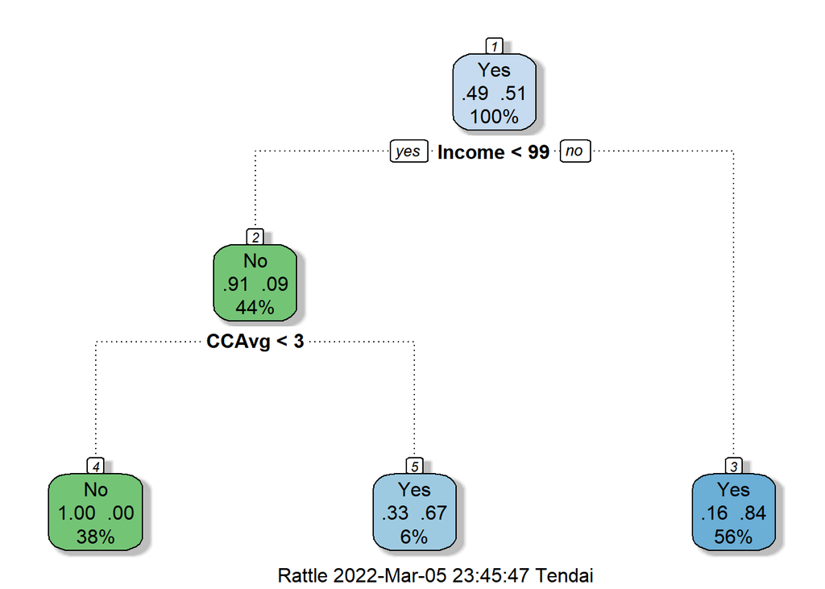

```r
ndata.tree1p <-
  prune(ndata.tree1, cp = cp)
fancyRpartPlot(ndata.tree1p)
```

We use fancyplot to print the first tree.

[figure not shown]

```r
fancyRpartPlot(ndata.tree1)
```

We predict the train result with ndata.tain for both trees then compared the pruned tree1p with the first tree1 and compare the results.

```r
pred.train.tree1  <- predict(ndata.tree1,  ndata.train)
pred.train.tree1p <- predict(ndata.tree1p, ndata.train)
```

# ROC curve values for both tree1 and tree1p

```r
ROC.train.tree1  <- roc(as.numeric(ndata.train$Personal_Loan == "Yes"),
                        pred.train.tree1[,1])
ROC.train.tree1p <- roc(as.numeric(ndata.train$Personal_Loan == "Yes"),
                        pred.train.tree1p[,1])
```

We plot the AUC to see how the models are performing. Models that perform well will have `gini` close to or equal to 1 then close to zero for non performing models.

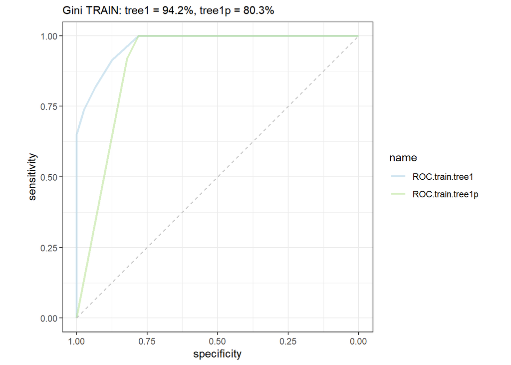

```r
list(
  ROC.train.tree1  = ROC.train.tree1,
  ROC.train.tree1p = ROC.train.tree1p
) %>%
  pROC::ggroc(alpha = 0.5, linetype = 1, size = 1) +
  geom_segment(aes(x = 1, xend = 0, y = 0, yend = 1),
               color = "grey",
               linetype = "dashed") +
  labs(subtitle = paste0("Gini TRAIN: ",
                         "tree1 = ",
                         round(100*(2 * auc(ROC.train.tree1) - 1), 1), "%, ",
                         "tree1p = ",
                         round(100*(2 * auc(ROC.train.tree1p) - 1), 1), "% ")) +
  theme_bw() + coord_fixed() +
  # scale_color_brewer(palette = "Paired") +
  scale_color_manual(values = RColorBrewer::brewer.pal(n = 4,
                                                       name = "Paired")[c(1, 3)])
```

The pruned model has a lower value of the Gini coefficient.We repeated the calculations for the testing set.

```r
pred.test.tree1  <- predict(ndata.tree1,
                            ndata.test)
pred.test.tree1p <- predict(ndata.tree1p,
                            ndata.test)
ROC.test.tree1  <- roc(as.numeric(ndata.test$Personal_Loan == "Yes"),
                       pred.test.tree1[, 1])
ROC.test.tree1p <- roc(as.numeric(ndata.test$Personal_Loan == "Yes"),
                       pred.test.tree1p[, 1])
```

We add the ROC curves to the previous plot.

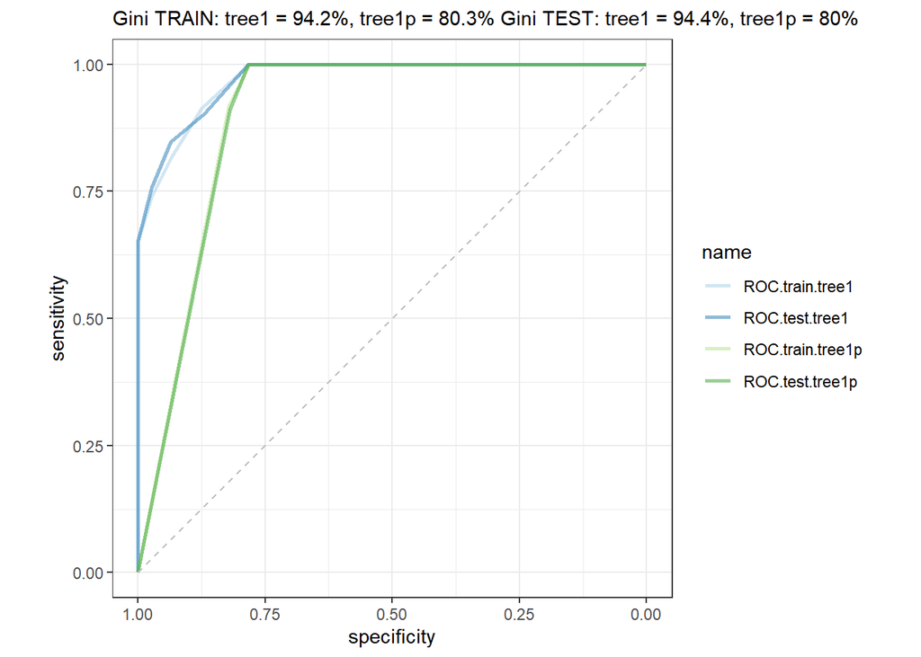

```r
list(
  ROC.train.tree1  = ROC.train.tree1,
  ROC.test.tree1   = ROC.test.tree1,
  ROC.train.tree1p = ROC.train.tree1p,
  ROC.test.tree1p  = ROC.test.tree1p
) %>%
  pROC::ggroc(alpha = 0.5, linetype = 1, size = 1) +
  geom_segment(aes(x = 1, xend = 0, y = 0, yend = 1),
               color = "grey",
               linetype = "dashed") +
  labs(subtitle = paste0("Gini TRAIN: ",
                         "tree1 = ",
                         round(100*(2 * auc(ROC.train.tree1) - 1), 1), "%, ",
                         "tree1p = ",
                         round(100*(2 * auc(ROC.train.tree1p) - 1), 1), "% ",
                         "Gini TEST: ",
                         "tree1 = ",
                         round(100*(2 * auc(ROC.test.tree1) - 1), 1), "%, ",
                         "tree1p = ",
                         round(100*(2 * auc(ROC.test.tree1p) - 1), 1), "% "
                         )) +
  theme_bw() + coord_fixed() +
  scale_color_brewer(palette = "Paired")
```

Tree1 model perfomed better in testing while model treep1 gave us lower results in the testing compared to the training data.

Alternatively, to estimate the tree we can use the `caret` package.

```r
tc <- trainControl(method = "cv",
                   number = 10,
                   classProbs = TRUE,
                   summaryFunction = twoClassSummary)
```

We define the range for values of the `cp` parameter for the cross validation process with respect to AUC (ROC) values.

```r
modelLookup("rpart")
```

```
##   model parameter                label forReg forClass probModel
## 1 rpart        cp Complexity Parameter   TRUE     TRUE      TRUE
```

```r
cp.grid <- expand.grid(cp = seq(0, 0.03, 0.001))
set.seed(12345)
ndata.tree2 <-
  train(model1.formula,
        data = ndata.train,
        method = "rpart",
        metric = "ROC",
        trControl = tc,
        tuneGrid  = cp.grid)
```

Below we can view the results.

```r
ndata.tree2
```

```
## CART
##
## 3500 samples
##   10 predictor
##    2 classes: 'No', 'Yes'
##
## No pre-processing
## Resampling: Cross-Validated (10 fold)
## Summary of sample sizes: 3149, 3150, 3150, 3151, 3149, 3150, ...
## Resampling results across tuning parameters:
##
##   cp     ROC        Sens       Spec
##   0.000  0.9895152  0.9380831  0.9664334
##   0.001  0.9893691  0.9357541  0.9686837
##   0.002  0.9887022  0.9345777  0.9614211
##   0.003  0.9843047  0.9153407  0.9625290
##   0.004  0.9759594  0.8989664  0.9546701
##   0.005  0.9711640  0.8919455  0.9518988
##   0.006  0.9693199  0.8849653  0.9558094
##   0.007  0.9515691  0.8546206  0.9641925
##   0.008  0.9287555  0.8236808  0.9736897
##   0.009  0.9226952  0.8131545  0.9820695
##   0.010  0.9109068  0.7926867  0.9899065
##   0.011  0.9057405  0.7839147  0.9932584
##   0.012  0.9012166  0.7804060  1.0000000
##   0.013  0.9012166  0.7804060  1.0000000
##   0.014  0.9012166  0.7804060  1.0000000
##   0.015  0.9012166  0.7804060  1.0000000
##   0.016  0.9012166  0.7804060  1.0000000
##   0.017  0.9012166  0.7804060  1.0000000
##   0.018  0.9012166  0.7804060  1.0000000
##   0.019  0.9012166  0.7804060  1.0000000
##   0.020  0.9012166  0.7804060  1.0000000
##   0.021  0.9012166  0.7804060  1.0000000
##   0.022  0.9012166  0.7804060  1.0000000
##   0.023  0.9012166  0.7804060  1.0000000
##   0.024  0.9012166  0.7804060  1.0000000
##   0.025  0.9012166  0.7804060  1.0000000
##   0.026  0.9012166  0.7804060  1.0000000
##   0.027  0.9012166  0.7804060  1.0000000
##   0.028  0.9012166  0.7804060  1.0000000
##   0.029  0.9012166  0.7804060  1.0000000
##   0.030  0.9012166  0.7804060  1.0000000
##
## ROC was used to select the optimal model using the largest value.
## The final value used for the model was cp = 0.
```

```r
pred.train.tree2 <- predict(ndata.tree2,
                            ndata.train)
ROC.train.tree2  <- roc(as.numeric(ndata.train$Personal_Loan == "Yes"),
                        pred.train.tree1[, 1])
pred.test.tree2  <- predict(ndata.tree2,
                            ndata.test)
ROC.test.tree2  <- roc(as.numeric(ndata.test$Personal_Loan == "Yes"),
                       pred.test.tree1[, 1])
cat("Gini train = ", 2 * ROC.train.tree2$auc - 1, "\n", sep = "")
```

```
## Gini train = 0.9420367
```

```r
cat("Gini test  = ", 2 * ROC.test.tree2$auc - 1,  "\n", sep = "")
```

```
## Gini test  = 0.9442037
```

## VARIABLE IMPORTANCE

From these results returned we can find importance of each predictor.

```r
tree1.importance <- ndata.tree1$variable.importance
tree1.importance
```

```
##       Income        CCAvg    Education          Age   Experience       Online
## 992.17297959 591.43654114 139.00771775   8.56197191   5.86926844   5.69110262
##   CD_Account     Mortgage
##   0.34103986   0.08525996
```

The measure of predictors importance is the sum of quality of those splits split performance for predictors . We can view the plot below

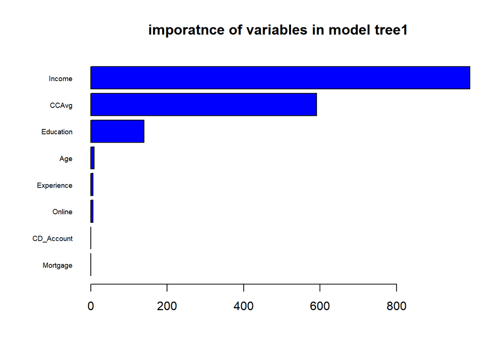

```r
# margins c(bottom, left, top, right)
# default c(5, 4, 4, 2) + 0.1.
par(mar = c(5.1, 6.1, 4.1, 2.1))
barplot(rev(tree1.importance), # vactor
        col = "blue",  # colors
        main = "imporatnce of variables in model tree1",
        horiz = T,  # horizontal type of plot
        las = 1,    # labels always horizontally
        cex.names = 0.6)
```

# ESEMBLING

Setting the parameters for cross-validation process.

```r
my_control <- trainControl(
  method = "boot",
  number = 25,
  savePredictions = "final",
  classProbs = TRUE,
  index = createResample(ndata.train$Personal_Loan, 25),
  summaryFunction = twoClassSummary
)
```

## Bottom-layer models, `caretList()`

We used ‘caretList’ function to estimate models for each of them we will use parameters that we defined in my control object.

```r
model_list <- caretList(
  Personal_Loan ~ .,
  data = ndata.train,
  metric = "ROC",
  trControl = my_control,
  methodList = c("glm", "rpart")
)
```

Merging predictions on the testing sample for the two models into one data frame.

```r
model_preds <-
  lapply(model_list, predict, newdata = ndata.test, type = "prob") %>%
  lapply(function(x) x[,"Yes"]) %>%
  data.frame()
```

Predictions calculations.

```r
p <- predict(model_list, newdata = ndata.test) %>% as.data.frame()
head(p, 10)
```

```
##           glm     rpart
## 1  0.99848285 1.0000000
## 2  0.99816207 1.0000000
## 3  0.85550416 1.0000000
## 4  0.96450193 1.0000000
## 5  0.34296965 0.1571941
## 6  0.96269993 1.0000000
## 7  0.91670447 1.0000000
## 8  0.99680568 1.0000000
## 9  0.01089826 0.1571941
## 10 0.97444272 1.0000000
```

Calculation of the values of the ROC curve for the considered models.

```r
ndata.ROC.test.glm <-
  roc(as.numeric(ndata.test$Personal_Loan == "Yes"),
      p[, "glm"])
ndata.ROC.test.rpart <-
  roc(as.numeric(ndata.test$Personal_Loan == "Yes"),
      p[, "rpart"])
```

Plotting the ROC curves

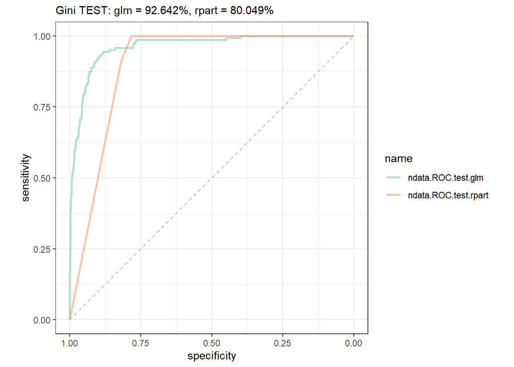

```r
list(
  ndata.ROC.test.glm    = ndata.ROC.test.glm,
  ndata.ROC.test.rpart  = ndata.ROC.test.rpart) %>%
  pROC::ggroc(alpha = 0.5, linetype = 1, size = 1) +
  geom_segment(aes(x = 1, xend = 0, y = 0, yend = 1),
               color = "grey",
               linetype = "dashed") +
  labs(subtitle = paste0("Gini TEST: ",
                         "glm = ",
                         round(100 * (2 * auc(ndata.ROC.test.glm) - 1), 3), "%, ",
                         "rpart = ",
                         round(100 * (2 * auc(ndata.ROC.test.rpart) - 1), 3), "% ")) +
  theme_bw() + coord_fixed() +
  scale_color_brewer(palette = "Set2")
```

```r
  gbm_ensemble <- caretStack(
    model_list,
    method = "gbm",
    verbose = FALSE,
    tuneLength = 10,
    metric = "ROC",
    trControl = trainControl(
      method = "boot",
      number = 10,
      savePredictions = "final",
      classProbs = TRUE,
      summaryFunction = twoClassSummary
    )
  )
```

We calculate the AUC for this model:

```r
model_preds$ensemble <- predict(gbm_ensemble, newdata = ndata.test, type = "prob")
caTools::colAUC(model_preds, ndata.test$Personal_Loan)
```

```
##                  glm     rpart  ensemble
## Yes vs. No 0.9632088 0.9002427 0.9670036
```

We present the ROC curve:

```r
ndata.ROC.test.ensemble <-
ndata.ROC.test.ensemble <-
  roc(as.numeric(ndata.test$Personal_Loan == "Yes"),
      model_preds$ensemble)
```

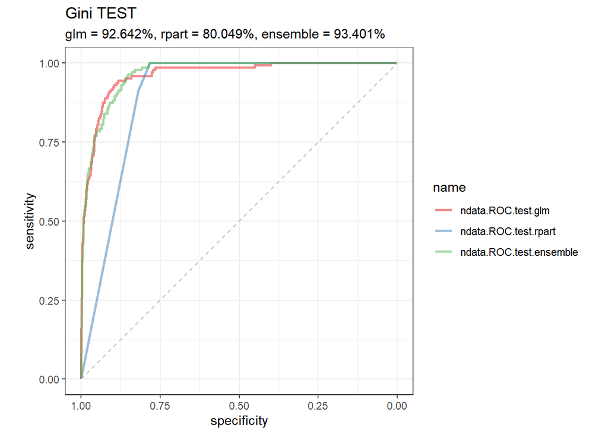

```r
list(
  ndata.ROC.test.glm       = ndata.ROC.test.glm,
  ndata.ROC.test.rpart     = ndata.ROC.test.rpart,
  ndata.ROC.test.ensemble = ndata.ROC.test.ensemble) %>%
  pROC::ggroc(alpha = 0.5, linetype = 1, size = 1) +
  geom_segment(aes(x = 1, xend = 0, y = 0, yend = 1),
               color = "grey",
               linetype = "dashed") +
  labs(
    title = "Gini TEST",
    subtitle = paste0("glm = ",
                      round(100 * (2 * auc(ndata.ROC.test.glm) - 1), 3), "%, ",
                      "rpart = ",
                      round(100 * (2 * auc(ndata.ROC.test.rpart) - 1), 3), "%, ",
                      "ensemble = ",
                      round(100 * (2 * auc(ndata.ROC.test.ensemble) - 1), 3), "% ")) +
  theme_bw() + coord_fixed() +
  scale_color_brewer(palette = "Set1")
```